# test

Group 2

2/17/2022

## Data Cleaning

Dropped 4 missing value, their IDs are MC381,MC389,MC393,MC76.

## Density Test

We would like to use the T-tests to find the difference of diets between two sites.

Firstly, we checked the normality.

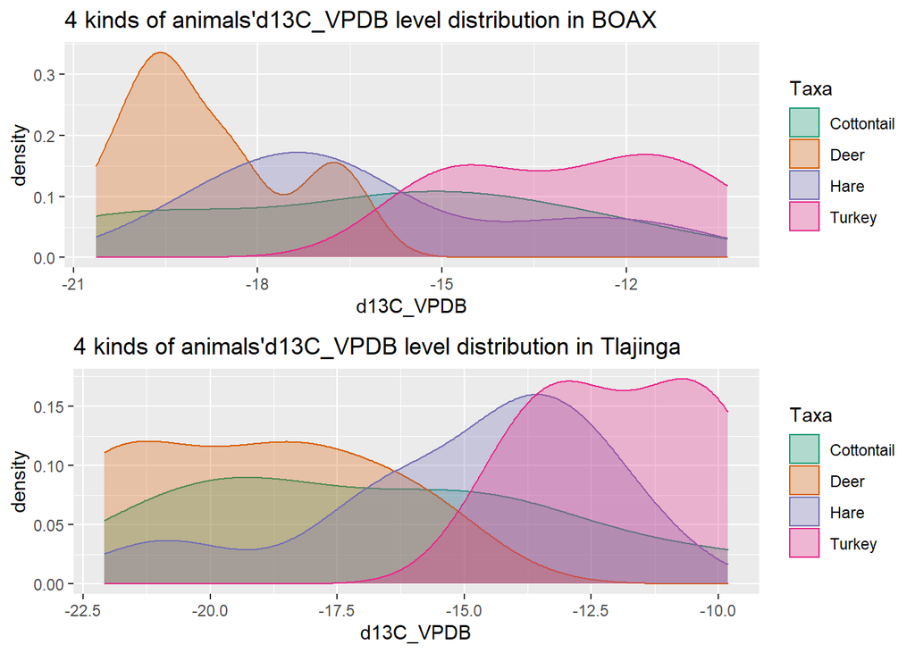

## Mann Whitney U Test

Mann-Whitney U Test for deer.

```
##
##  Wilcoxon rank sum exact test
##
## data:  value by Site
## W = 43, p-value = 0.8633
## alternative hypothesis: true location shift is not equal to 0
```

```
##
##  Wilcoxon rank sum exact test
##
## data:  value by Site
## W = 41, p-value = 0.673
## alternative hypothesis: true location shift is not equal to 0
```

```
##
##  Wilcoxon rank sum test with continuity correction
##
## data:  value by Site
## W = 51.5, p-value = 0.3536
## alternative hypothesis: true location shift is not equal to 0
```

Mann-Whitney U Test for Cottontail.

```
##
##  Wilcoxon rank sum exact test
##
## data:  value by Site
## W = 38, p-value = 0.8884
## alternative hypothesis: true location shift is not equal to 0
```

```
##
##  Wilcoxon rank sum exact test
##
## data:  value by Site
## W = 43, p-value = 0.5414
## alternative hypothesis: true location shift is not equal to 0
```

```
##
##  Wilcoxon rank sum exact test
##
## data:  value by Site
## W = 52, p-value = 0.03792
## alternative hypothesis: true location shift is not equal to 0
```

Mann-Whitney U Test for Hare.

```
##
##  Wilcoxon rank sum exact test
##
## data:  value by Site
## W = 32, p-value = 0.3511
## alternative hypothesis: true location shift is not equal to 0
```

```
##
##  Wilcoxon rank sum test with continuity correction
##
## data:  value by Site
## W = 45, p-value = 0.9671
## alternative hypothesis: true location shift is not equal to 0
```

```
##
##  Wilcoxon rank sum exact test
##
## data:  value by Site
## W = 50, p-value = 0.6574
## alternative hypothesis: true location shift is not equal to 0
```

Mann-Whitney U Test for Turkey.

```
##
##  Wilcoxon rank sum test with continuity correction
##
## data:  value by Site
## W = 15.5, p-value = 0.3012
## alternative hypothesis: true location shift is not equal to 0
```

```
##
##  Wilcoxon rank sum exact test
##
## data:  value by Site
## W = 36, p-value = 0.1419
## alternative hypothesis: true location shift is not equal to 0
```

```
##
##  Wilcoxon rank sum test with continuity correction
##
## data:  value by Site
## W = 32.5, p-value = 0.3012
## alternative hypothesis: true location shift is not equal to 0
```

waining mean: The impact of ties means the Wilcoxon rank sum distribution cannot be used to calculate exact p-values. If ties occur in our data and we have fewer than 50 observations, the wilcox.test function returns a normal approximated p-value along with a warning message that says “cannot compute exact p-value with ties”.

Since this p-value is not less than 0.05, we fail to reject the null hypothesis.

- Mann-Whitney U Test for Cottontail.

W=52, p-value= 0.03792

we can reject the null hypothesis: two sites animals are the same

## Check Mann-Whitney U Test with theory

Because we find that Cottontail of d15N_air test reject the null hypothesis due to p-value. We want to check Mann-Whitney U Test without R package again.

Alpha=0.01, test statistic(7) and our critical value(7) cannot reject

Theory : https://www.statology.org/mann-whitney-u-test/ Table : https://www.statology.org/mann-whitney-u-table/

## Next Step

We plan to try some statistic test or some regression to compare the isotopes level in two sites more precisely.

Two-Sample T-tests are as followings:

### “d13C_VPDB” level

```r
# Assumption
# H0 : v1  = v2
# Ha : v1 != v2
```

```r
# "d13C_VPDB" level in turkey groups
test.turkey.d13C <- filter(aggdata, Taxa == "Turkey" & variable== "d13C_VPDB")
with(test.turkey.d13C, shapiro.test(value[Site == "BAOX"])) # p = 0.4606
```

```
##
##  Shapiro-Wilk normality test
##
## data:  value[Site == "BAOX"]
## W = 0.9237, p-value = 0.4606
```

```r
with(test.turkey.d13C, shapiro.test(value[Site == "Tlajinga"])) # p = 0.7027
```

```
##
##  Shapiro-Wilk normality test
##
## data:  value[Site == "Tlajinga"]
## W = 0.94538, p-value = 0.7027
```

```r
# From the output, the two p-values are greater than the significance level 0.05 implying that the distribution of the data are not significantly different from the normal distribution. In other words, we can assume the normality.

t.test(value ~ Site, data = test.turkey.d13C, var.equal = TRUE)
```

```
##
##  Two Sample t-test
##
## data:  value by Site
## t = -1.0102, df = 12, p-value = 0.3323
## alternative hypothesis: true difference in means between group BAOX and group Tlajinga is not equal to 0
## 95 percent confidence interval:
##  -3.113316  1.140816
## sample estimates:
##     mean in group BAOX mean in group Tlajinga
##              -12.89625              -11.91000
```

```r
# p = 0.3323
# Not reject!
```

```r
# "d13C_VPDB" level in Cottontail groups
test.Cottontail.d13C <- filter(aggdata, Taxa == "Cottontail" & variable== "d13C_VPDB")
with(test.Cottontail.d13C, shapiro.test(value[Site == "BAOX"])) # p = 0.5969
```

```
##
##  Shapiro-Wilk normality test
##
## data:  value[Site == "BAOX"]
## W = 0.94142, p-value = 0.5969
```

```r
with(test.Cottontail.d13C, shapiro.test(value[Site == "Tlajinga"])) # p = 0.3941
```

```
##
##  Shapiro-Wilk normality test
##
## data:  value[Site == "Tlajinga"]
## W = 0.91546, p-value = 0.3941
```

```r
# From the output, the two p-values are greater than the significance level 0.05 implying that the distribution of the data are not significantly different from the normal distribution. In other words, we can assume the normality.
t.test(value ~ Site, data = test.Cottontail.d13C, var.equal = TRUE)
```

```
##
##  Two Sample t-test
##
## data:  value by Site
## t = 0.23657, df = 15, p-value = 0.8162
## alternative hypothesis: true difference in means between group BAOX and group Tlajinga is not equal to 0
## 95 percent confidence interval:
##  -3.187167  3.983000
## sample estimates:
##     mean in group BAOX mean in group Tlajinga
##              -16.26333              -16.66125
```

```r
# p = 0.8162
# Not reject!
```

```r
# "d13C_VPDB" level in Deer groups
test.Deer.d13C <- filter(aggdata, Taxa == "Deer" & variable== "d13C_VPDB")
with(test.Deer.d13C, shapiro.test(value[Site == "BAOX"])) # p = 0.3914
```

```
##
##  Shapiro-Wilk normality test
##
## data:  value[Site == "BAOX"]
## W = 0.9199, p-value = 0.3914
```

```r
with(test.Deer.d13C, shapiro.test(value[Site == "Tlajinga"])) # p = 0.2177
```

```
##
##  Shapiro-Wilk normality test
##
## data:  value[Site == "Tlajinga"]
## W = 0.89371, p-value = 0.2177
```

```r
# From the output, the two p-values are greater than the significance level 0.05 implying that the distribution of the data are not significantly different from the normal distribution. In other words, we can assume the normality.
t.test(value ~ Site, data = test.Deer.d13C, var.equal = TRUE)
```

```
##
##  Two Sample t-test
##
## data:  value by Site
## t = 0.44023, df = 16, p-value = 0.6657
## alternative hypothesis: true difference in means between group BAOX and group Tlajinga is not equal to 0
## 95 percent confidence interval:
##  -1.581292  2.410181
## sample estimates:
##     mean in group BAOX mean in group Tlajinga
##              -18.83333              -19.24778
```

```r
# p = 0.6657
# Not reject!
```

```r
# "d13C_VPDB" level in Hare groups
test.Hare.d13C <- filter(aggdata, Taxa == "Hare" & variable== "d13C_VPDB")
with(test.Hare.d13C, shapiro.test(value[Site == "BAOX"])) # p = 0.2707
```

```
##
##  Shapiro-Wilk normality test
##
## data:  value[Site == "BAOX"]
## W = 0.91386, p-value = 0.2707
```

```r
with(test.Hare.d13C, shapiro.test(value[Site == "Tlajinga"])) # p = 0.2447
```

```
##
##  Shapiro-Wilk normality test
##
## data:  value[Site == "Tlajinga"]
## W = 0.89208, p-value = 0.2447
```

```r
# From the output, the two p-values are greater than the significance level 0.05 implying that the distribution of the data are not significantly different from the normal distribution. In other words, we can assume the normality.

t.test(value ~ Site, data = test.Hare.d13C, var.equal = TRUE)
```

```
##
##  Two Sample t-test
##
## data:  value by Site
## t = -0.86338, df = 17, p-value = 0.3999
## alternative hypothesis: true difference in means between group BAOX and group Tlajinga is not equal to 0
## 95 percent confidence interval:
##  -3.790379  1.589015
## sample estimates:
##     mean in group BAOX mean in group Tlajinga
##              -16.15818              -15.05750
```

```r
# p = 0.3999
# Not reject!
```

### “d15N_air” level

```r
# "d15N_air" level in turkey groups
test.turkey.d15N <- filter(aggdata, Taxa == "Turkey" & variable== "d15N_air")
with(test.turkey.d15N, shapiro.test(value[Site == "BAOX"])) # p = 0.7717
```

```
##
##  Shapiro-Wilk normality test
##
## data:  value[Site == "BAOX"]
## W = 0.95604, p-value = 0.7717
```

```r
with(test.turkey.d15N, shapiro.test(value[Site == "Tlajinga"])) # p = 0.4532
```

```
##
##  Shapiro-Wilk normality test
##
## data:  value[Site == "Tlajinga"]
## W = 0.91253, p-value = 0.4532
```

```r
# From the output, the two p-values are greater than the significance level 0.05 implying that the distribution of the data are not significantly different from the normal distribution. In other words, we can assume the normality.

t.test(value ~ Site, data = test.turkey.d15N, var.equal = TRUE)
```

```
##
##  Two Sample t-test
##
## data:  value by Site
## t = 1.261, df = 12, p-value = 0.2313
## alternative hypothesis: true difference in means between group BAOX and group Tlajinga is not equal to 0
## 95 percent confidence interval:
##  -0.7365794  2.7607460
## sample estimates:
##     mean in group BAOX mean in group Tlajinga
##               8.323750               7.311667
```

```r
# p = 0.2313
# Not reject!
```

```r
# "d15N_air" level in Cottontail groups
test.Cottontail.d15N <- filter(aggdata, Taxa == "Cottontail" & variable== "d15N_air")
with(test.Cottontail.d15N, shapiro.test(value[Site == "BAOX"])) # p = 0.9938
```

```
##
##  Shapiro-Wilk normality test
##
## data:  value[Site == "BAOX"]
## W = 0.98923, p-value = 0.9938
```

```r
with(test.Cottontail.d15N, shapiro.test(value[Site == "Tlajinga"])) # p = 0.2703
```

```
##
##  Shapiro-Wilk normality test
##
## data:  value[Site == "Tlajinga"]
## W = 0.89679, p-value = 0.2703
```

```r
# From the output, the two p-values are greater than the significance level 0.05 implying that the distribution of the data are not significantly different from the normal distribution. In other words, we can assume the normality.
t.test(value ~ Site, data = test.Cottontail.d15N, var.equal = TRUE)
```

```
##
##  Two Sample t-test
##
## data:  value by Site
## t = 2.423, df = 14, p-value = 0.02954
## alternative hypothesis: true difference in means between group BAOX and group Tlajinga is not equal to 0
## 95 percent confidence interval:
##  0.2135756 3.5064244
## sample estimates:
##     mean in group BAOX mean in group Tlajinga
##                  6.165                  4.305
```

```r
# p = 0.02954 < 0.05
# Reject!
```

```r
# "d15N_air" level in Deer groups
test.Deer.d15N <- filter(aggdata, Taxa == "Deer" & variable== "d15N_air")
with(test.Deer.d15N, shapiro.test(value[Site == "BAOX"])) # p = 0.5592
```

```
##
##  Shapiro-Wilk normality test
##
## data:  value[Site == "BAOX"]
## W = 0.93783, p-value = 0.5592
```

```r
with(test.Deer.d15N, shapiro.test(value[Site == "Tlajinga"])) # p = 0.7696
```

```
##
##  Shapiro-Wilk normality test
##
## data:  value[Site == "Tlajinga"]
## W = 0.9573, p-value = 0.7696
```

```r
# From the output, the two p-values are greater than the significance level 0.05 implying that the distribution of the data are not significantly different from the normal distribution. In other words, we can assume the normality.
t.test(value ~ Site, data = test.Deer.d15N, var.equal = TRUE)
```

```
##
##  Two Sample t-test
##
## data:  value by Site
## t = 1.0472, df = 16, p-value = 0.3106
## alternative hypothesis: true difference in means between group BAOX and group Tlajinga is not equal to 0
## 95 percent confidence interval:
##  -0.6111782  1.8045115
## sample estimates:
##     mean in group BAOX mean in group Tlajinga
##               5.270000               4.673333
```

```r
# p = 0.3106
# Not reject!
```

```r
# "d15N_air" level in Hare groups
test.Hare.d15N <- filter(aggdata, Taxa == "Hare" & variable== "d15N_air")
with(test.Hare.d15N, shapiro.test(value[Site == "BAOX"])) # p = 0.3232
```

```
##
##  Shapiro-Wilk normality test
##
## data:  value[Site == "BAOX"]
## W = 0.92055, p-value = 0.3232
```

```r
with(test.Hare.d15N, shapiro.test(value[Site == "Tlajinga"])) # p = 0.4432
```

```
##
##  Shapiro-Wilk normality test
##
## data:  value[Site == "Tlajinga"]
## W = 0.92163, p-value = 0.4432
```

```r
# From the output, the two p-values are greater than the significance level 0.05 implying that the distribution of the data are not significantly different from the normal distribution. In other words, we can assume the normality.

t.test(value ~ Site, data = test.Hare.d15N, var.equal = TRUE)
```

```
##
##  Two Sample t-test
##
## data:  value by Site
## t = 0.86085, df = 17, p-value = 0.4013
## alternative hypothesis: true difference in means between group BAOX and group Tlajinga is not equal to 0
## 95 percent confidence interval:
##  -1.148160  2.730887
## sample estimates:
##     mean in group BAOX mean in group Tlajinga
##               6.276364               5.485000
```

```r
# p = 0.4013
# Not reject!
```